# Capstone Final Report - London house prices

Jaymin Mistry

22 April 2017

### Problem

Property prices in London are already high, this is partly due to large demand and insufficient supply. I want to understand the factors that contribute to differences in house prices for similar type properties within the Greater London area with open source data (access to transport, facilities, schooling etc). I am curious whether there are factors that are not normally considered when searching for a property that affect values and what weighting they have relative to each other.

### Audience and output

This information will primarily be useful to anyone considering purchasing a property in London. It would also be useful for estate agents and the property listing websites in the UK (Zoopla, Rightmove and Onthemarket) to identify trends.

For house purchasers, this may highlight areas, which are underpriced and offer good value. Alternatively it may highlight areas, which have similar characteristics but are not regularly considered. For estate agents and property websites, it could provide a guide to understanding what people are actually looking for and therefore provide alternatives. This information would be useful for central and local government in understanding people’s desires and requirements when choosing a home and could therefore focus where resources and effort is spent on development.

### What important fields and information does the data set have?

The Land registry dataset contains price paid, date of sale and the property type. It also includes whether it is a freehold or leasehold property and it indicates whether it is a new build property or not. This will only allow me to infer the age of properties built since 1995.

The Metropolitan crime dataset breaks down crime rates into major and minor categories and is split down into anonymised areas at LSOA (Lower Layer Super Output Area) level with a mean size of 1500 people.

There is a huge amount of data available for schooling across the Uk, including money spent the pupil, GCSE results (aged 16), school leaver destinations and A level results (age 18) and destination. I have decided to use GCSE results as a proxy for school quality. GCSE results are a broad indicator of A level performance and therefore overall school performance.

### Limitations i.e. what are some questions that you cannot answer with this data set?

The key difficulty I faced is that I am attempting to correlate geospatial data in R. Constructing geospatial models to calculate times is possible but difficult in R and a distraction from the problem I am attempting to solve. Using absolute distance from a central point is possible would mask regions, which are centrally located but poorly served by public transport and vice versa. There is a google maps distance matrix API, which can provide journey times via public transport. However it is limited to 2.5k queries a day.

2. I have not been able to acquire data on the number of rooms. I assess this is a major factor in house prices but I cannot get access to any dataset containing this information.
3. I have not found a data set containing ages of property (although this can be deduced for new build properties since 1995)
4. Crime data is anonymised to month and LSOA.
5. It is impossible to see whether children go to school across council boundaries or attend boarding school. I am therefore going to assume that the majority of children attend schools within their council area.

### A deeper dive into the data set:

The key data set is the prices paid for property from the Land Registry, which lists the majority of property sales since 1995.

```r
summary(london16)
```

```
##       X.1               X             Postcode        Price....
##  Min.   :     1   Min.   :     1   SE85EW :   100   Min.   :       1
##  1st Qu.: 28914   1st Qu.: 28914   HA90FW :    89   1st Qu.:  320000
##  Median : 57826   Median : 57826   TW80HT :    87   Median :  435000
##  Mean   : 57826   Mean   : 57826   E149AY :    86   Mean   :  674291
##  3rd Qu.: 86739   3rd Qu.: 86739   E149BU :    85   3rd Qu.:  635000
##  Max.   :115651   Max.   :115651   (Other):114839   Max.   :96840522
##                                    NA's   :   365
##  Property.Type New        Freehold.Leasehold      SAON
##  D: 4940       N:100775   F:49825            FLAT 1 : 2115
##  F:62652       Y: 14876   L:65826            FLAT 2 : 2112
##  O: 4952                                     FLAT 3 : 1934
##  S:14232                                     FLAT 4 : 1575
##  T:28875                                     FLAT 5 : 1214
##                                              (Other):36004
##                                              NA's   :70697
##      Number                 Road               Locality
##  1      :  1912   HIGH STREET :   588   CHEAM      :   469
##  4      :  1719   STATION ROAD:   443   WALTHAMSTOW:   323
##  5      :  1562   LONDON ROAD :   404   CRAYFORD   :   225
##  3      :  1491   CITY ROAD   :   365   STREATHAM  :   208
##  2      :  1462   HIGH ROAD   :   335   ICKENHAM   :   186
##  6      :  1348   (Other)     :113506   (Other)    :  5867
##  (Other):106157   NA's        :    10   NA's       :108373
##    Town.City              District       Date.of.Transfer
##  LONDON :68428   WANDSWORTH   : 5975   2016-03-31:  4847
##  ROMFORD: 2772   CROYDON      : 5827   2016-03-30:  2826
##  CROYDON: 2499   BROMLEY      : 5514   2016-03-24:  2121
##  ILFORD : 1905   BARNET       : 5512   2016-01-29:  1490
##  ENFIELD: 1845   TOWER HAMLETS: 4886   2016-03-29:  1362
##  HARROW : 1760   LEWISHAM     : 4456   2016-03-18:  1308
##  (Other):36442   (Other)      :83481   (Other)   :101697
##  PPD.Category.Type                        Transaction.unique.identifier
##  A:98630           {2AC10E4F-1085-1AF6-E050-A8C063052BA1}:     1
##  B:17021           {2AC10E4F-1087-1AF6-E050-A8C063052BA1}:     1
##                    {2AC10E4F-1088-1AF6-E050-A8C063052BA1}:     1
##                    {2AC10E4F-1089-1AF6-E050-A8C063052BA1}:     1
##                    {2AC10E4F-108C-1AF6-E050-A8C063052BA1}:     1
##                    {2AC10E4F-108D-1AF6-E050-A8C063052BA1}:     1
##                    (Other)                               :115645
##                             address         pricebracket
##  NYLAND COURT + SE8 5EW         :   100   300-400k:25676
##  CEDAR HOUSE + HA9 0FW          :    89   500-750k:24346
##  CHARRINGTON TOWER, 11 + E14 9AY:    86   400-500k:20412
##  QUAYSIDE HOUSE, 8 + TW8 0HT    :    86   200-300k:17325
##  TALISMAN TOWER, 6 + E14 9BU    :    85   1-5Mil  :10648
##  CANALETTO TOWER, 257 + EC1V 1AE:    83   (Other) :17081
##  (Other)                        :115122   NA's    :  163
```

The subset of the prices paid data extracted from the Land Registry, shows the postcode, price paid, type of property, whether it is a new build or not, further address information, sale date and a unique transaction ID. To this, I have added a address field in one box and categorised each property into a price bracket. Early examination of the crime dataset suggested that the amount of crime in the City of London District is disproportionate to its population. This may be due to the large numbers of tourists and workers, who do not reside in the District but visit in the day.

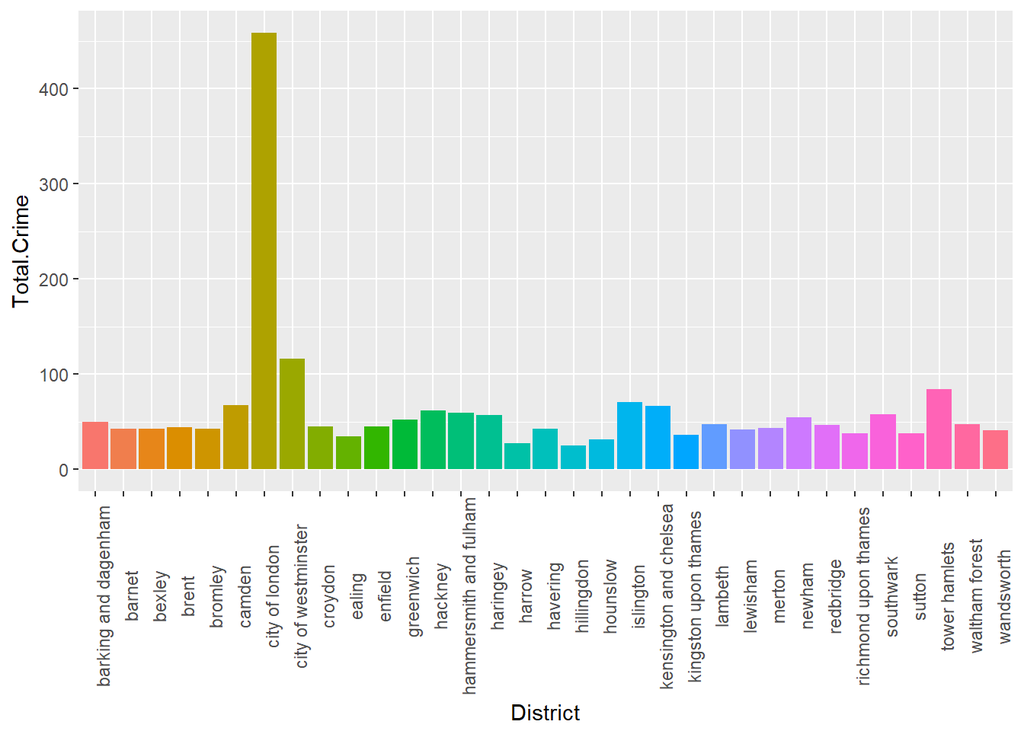

```r
ggplot(master, aes(District, Total.Crime, fill = District)) +
         geom_bar(stat= "Identity")+
 theme(axis.text.x = element_text(angle = 90))+
  theme(legend.position="none")
```

### What kind of cleaning and wrangling did you need to do?

The Land Registry Dataset was downloaded complete with all transactions from 1995 to the present day, the file was 3.8Gb. This was split into 10 segments, imported and filtered in R to give ~ 3 million property transactions in London. From this I extracted all sales from 1 Jan 16 till present (13 months), which yielded ~115k sales.

To minimise the number of queries I need, I have simplified it to unique postcodes, for which there are ~60k. I have used the google maps distance API via gmapsdistance package in R to calculate the journey time for each address. I sampled this dataset to collect a random portion, as I was limited to the number of queries I could make.

### Gmapsdistance API.

To calculate journey times and therefore assign a value to how accessible each address is, I used the Google maps distance matrix API to calculate the time a public transport journey would take from a postcode to a point in central London (in this case UCL: WC1 6BT). This score I am using a proxy for accessibility to transport. This is imperfect as many people do not work in the city centre, some drive to work and some people commute out of London, it provides the best numerical score without constructing my own spatial models.

There was a limit of 2500 requests per day, so I have randomly sampled 10,000 postcodes from the dataset to calculate times for. As postcodes cover a small geographical area, there is minimal time difference between the different addresses within each.

```r
temp <- gmapsdistance(set.api.key("xxx"),
                         origin = london2[1:500,1],
                         destination = "WC1E6BT",
                         mode = "transit",
                         dep_date = "2017-05-02",
                         dep_time = "09:00:00",
                         combinations = "all")
```

This produces 3 lists, which are then manipulated with a lapply function to produce a single dataframe.

```r
res <- data.frame(origin = london1[, 1],
                  desination = 'WC1E6BT',
                  do.call(data.frame, lapply(temp, function(x) x[, 2])))
```

The final output is a time in seconds to make a journey from the start postcode to WC1 6BT, using the best combination of walking and public transport.

# Preliminary Exploration

Having examined the prices for London property sold since 1 Jan 16, I explored the type and value of properties sold in this period.

## Histogram showing the different types of properties sold

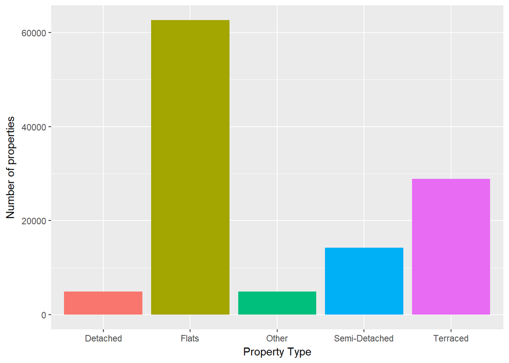

```r
prop.labels <- c("Detached", "Flats", "Other", "Semi-Detached", "Terraced")
ggplot(london16, aes(x = london16$Property.Type, fill = london16$Property.Type)) +
 geom_histogram(stat = "count") +
     xlab("Property Type") +
     ylab("Number of properties") +
   scale_x_discrete(labels= prop.labels) +
  theme(legend.position="none")
```

## Histogram showing distibution of property sold for each price bracket

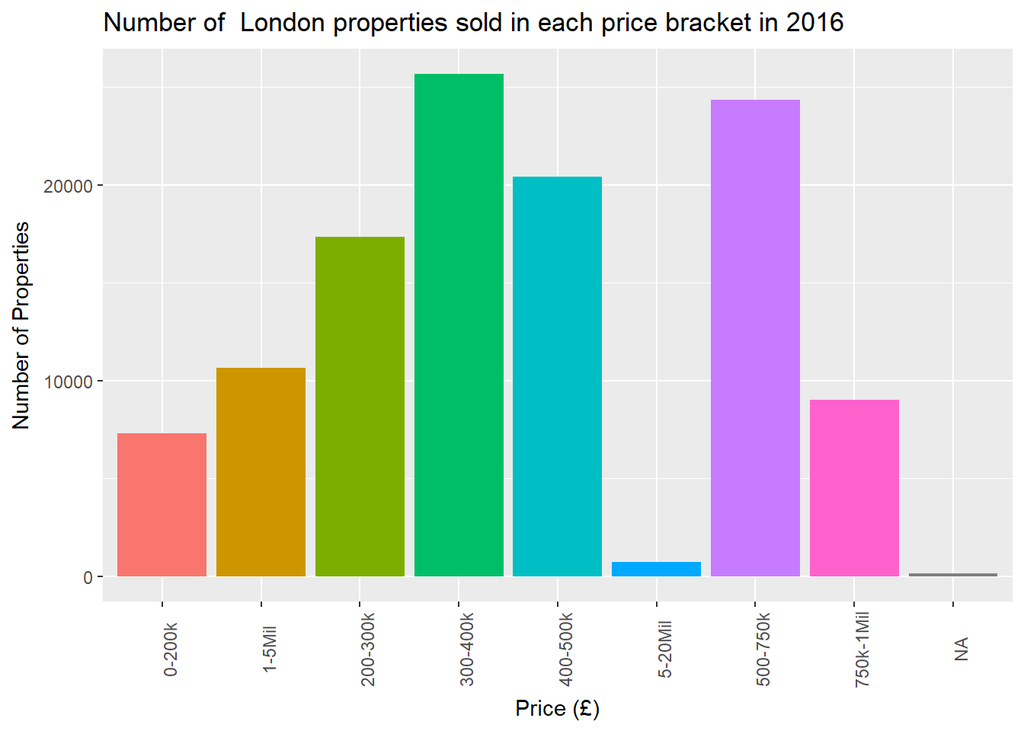

```r
 require(scales)
 hist <- ggplot(london16, aes(x = london16$pricebracket))+
     geom_histogram(stat="count",  aes(fill = london16$pricebracket)) +
     xlab("Price (£)") +
     ylab("Number of Properties") +
     theme(axis.text.x = element_text(angle =90)) +
     theme(legend.position="none")+
     ggtitle("Number of  London properties sold in each price bracket in 2016")
 hist
```

As expected the majority of the properties sold are in the central value of 200-750k, with fewer cheap or expensive properties being sold. There are also 163, which do not have a transaction value listed with them, marked as ‘NA’. I will remove these from the dataset.

## Sales by district

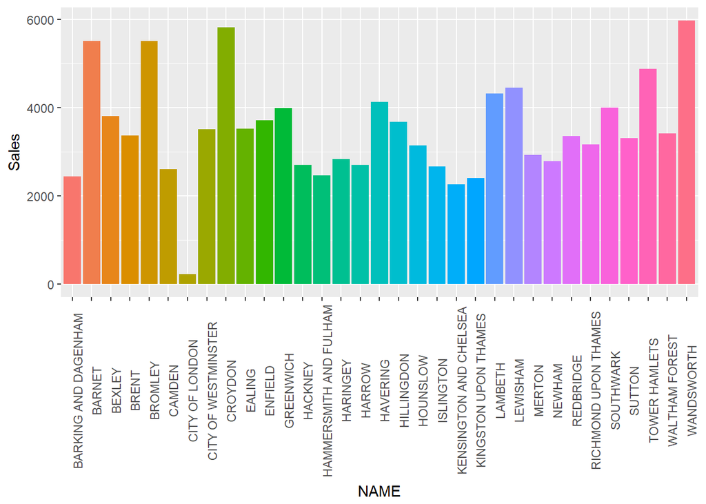

```r
ggplot(salesbydistrict, aes(x = NAME, y = Sales, fill = NAME)) +      geom_bar(stat = "identity") +
     theme(axis.text.x = element_text(angle = 90)) +
     theme(legend.position = "none")
```

As a key outlier, the City of London has significantly fewer sales, most likely due to its small size and population.

### Approach taken

After collecting results from the Gmaps API, I added these times and distance to the price paid data along with crime and education information. This dataset had 11,040 unique values.

I then tested a variety of linear regression models

## Model

### Time

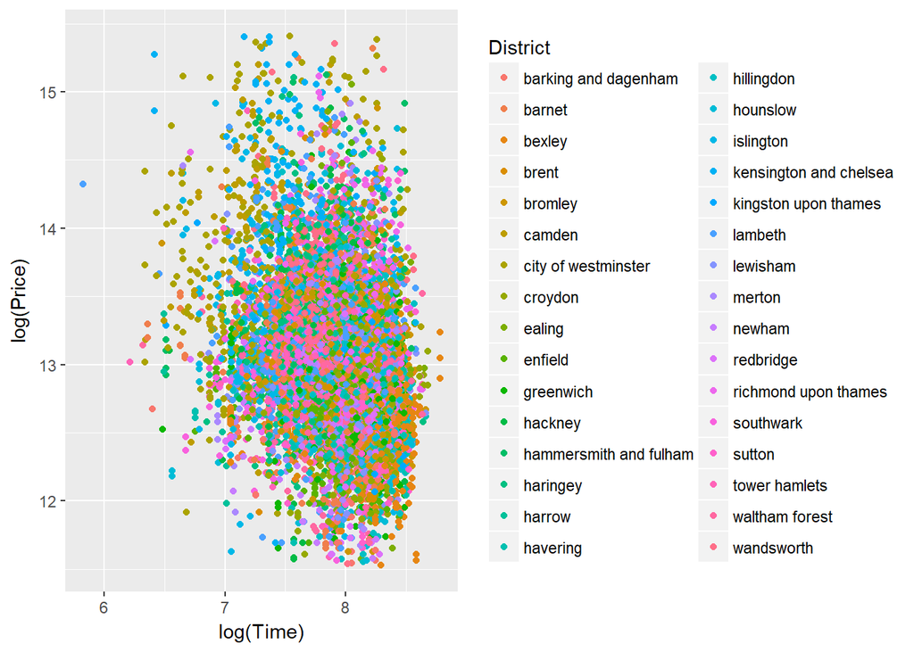

```r
qplot(log(Time), log(Price), data = london.complete, colour = District)
```

Examining the scatterplot of log(time) vs log(Price) demonstrates few no discernable trends. Fitting a regression line for each District results in a positive correlation in some cases but is mainly inconclusve.

```r
prop.model.time <- lm(log(Price)~ log(Time), london.complete)
summary(prop.model.time)
```

```
##
## Call:
## lm(formula = log(Price) ~ log(Time), data = london.complete)
##
## Residuals:
##      Min       1Q   Median       3Q      Max
## -1.73476 -0.33986 -0.04953  0.28485  2.47435
##
## Coefficients:
##             Estimate Std. Error t value Pr(>|t|)
## (Intercept) 16.03783    0.11176  143.50   <2e-16 ***
## log(Time)   -0.37882    0.01407  -26.92   <2e-16 ***
## ---
## Signif. codes:  0 '***' 0.001 '**' 0.01 '*' 0.05 '.' 0.1 ' ' 1
##
## Residual standard error: 0.5404 on 10917 degrees of freedom
## Multiple R-squared:  0.06225,    Adjusted R-squared:  0.06216
## F-statistic: 724.7 on 1 and 10917 DF,  p-value: < 2.2e-16
```

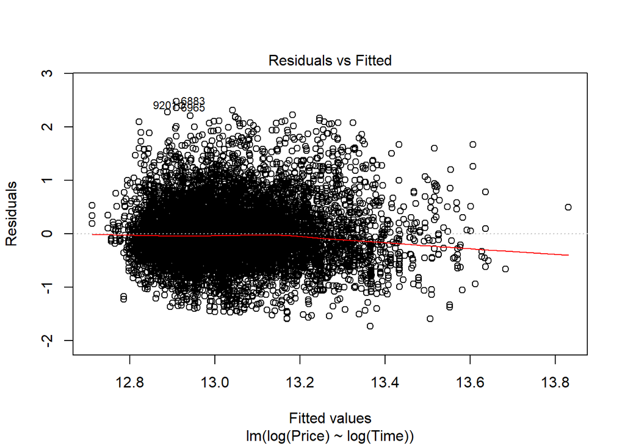

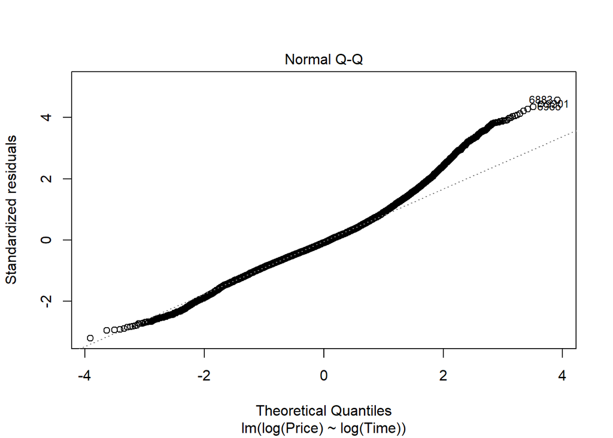

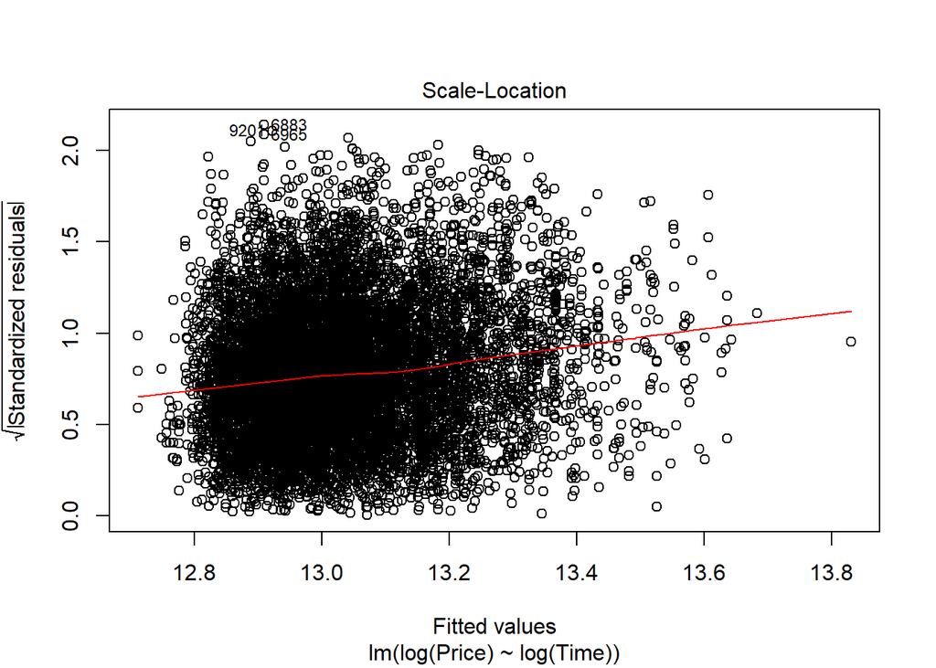

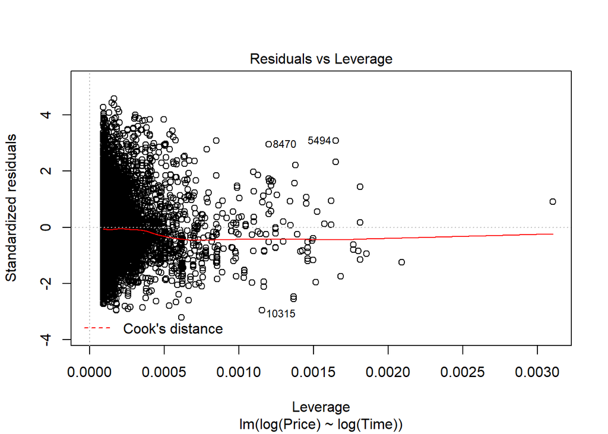

```r
plot(prop.model.time)
```

```r
prop.model.crime <- lm(Price~ Rate, london.complete)
prop.model.crime2 <- lm(Price~ Total.Crime, london.complete)
summary(prop.model.crime)
```

```
##
## Call:
## lm(formula = Price ~ Rate, data = london.complete)
##
## Residuals:
##     Min      1Q  Median      3Q     Max
## -968775 -211981  -86536   83577 4207141
##
## Coefficients:
##             Estimate Std. Error t value Pr(>|t|)
## (Intercept) 222031.1     9427.5   23.55   <2e-16 ***
## Rate         16847.5      441.7   38.14   <2e-16 ***
## ---
## Signif. codes:  0 '***' 0.001 '**' 0.01 '*' 0.05 '.' 0.1 ' ' 1
##
## Residual standard error: 414500 on 10917 degrees of freedom
## Multiple R-squared:  0.1176, Adjusted R-squared:  0.1175
## F-statistic:  1455 on 1 and 10917 DF,  p-value: < 2.2e-16
```

```r
summary(prop.model.crime2)
```

```
##
## Call:
## lm(formula = Price ~ Total.Crime, data = london.complete)
##
## Residuals:
##     Min      1Q  Median      3Q     Max
## -936440 -213874  -95076   76992 4209533
##
## Coefficients:
##             Estimate Std. Error t value Pr(>|t|)
## (Intercept) 162807.4    12561.4   12.96   <2e-16 ***
## Total.Crime   7948.8      245.3   32.40   <2e-16 ***
## ---
## Signif. codes:  0 '***' 0.001 '**' 0.01 '*' 0.05 '.' 0.1 ' ' 1
##
## Residual standard error: 421400 on 10917 degrees of freedom
## Multiple R-squared:  0.08772,    Adjusted R-squared:  0.08763
## F-statistic:  1050 on 1 and 10917 DF,  p-value: < 2.2e-16
```

```r
prop.model.edu <- lm(Price~ avegcse_ptscore, london.complete)
summary(prop.model.edu)
```

```
##
## Call:
## lm(formula = Price ~ avegcse_ptscore, data = london.complete)
##
## Residuals:
##     Min      1Q  Median      3Q     Max
## -480617 -227046 -117658   60543 4370452
##
## Coefficients:
##                 Estimate Std. Error t value Pr(>|t|)
## (Intercept)       4252.9    92584.1   0.046    0.963
## avegcse_ptscore   1396.7      237.5   5.882 4.18e-09 ***
## ---
## Signif. codes:  0 '***' 0.001 '**' 0.01 '*' 0.05 '.' 0.1 ' ' 1
##
## Residual standard error: 440500 on 10917 degrees of freedom
## Multiple R-squared:  0.003159,   Adjusted R-squared:  0.003067
## F-statistic: 34.59 on 1 and 10917 DF,  p-value: 4.181e-09
```

```r
prop.model.type <- lm(Price~ Property.Type, london.complete)
summary(prop.model.type)
```

```
##
## Call:
## lm(formula = Price ~ Property.Type, data = london.complete)
##
## Residuals:
##     Min      1Q  Median      3Q     Max
## -736439 -220324 -110873   64676 4453676
##
## Coefficients:
##                Estimate Std. Error t value Pr(>|t|)
## (Intercept)      916439      19313   47.45   <2e-16 ***
## Property.TypeF  -451116      20111  -22.43   <2e-16 ***
## Property.TypeS  -295792      22441  -13.18   <2e-16 ***
## Property.TypeT  -305567      20741  -14.73   <2e-16 ***
## ---
## Signif. codes:  0 '***' 0.001 '**' 0.01 '*' 0.05 '.' 0.1 ' ' 1
##
## Residual standard error: 427900 on 10915 degrees of freedom
## Multiple R-squared:  0.05952,    Adjusted R-squared:  0.05927
## F-statistic: 230.3 on 3 and 10915 DF,  p-value: < 2.2e-16
```

```r
prop.model.overall <- lm(Price~ Total.Crime + Population + Property.Type, london.complete)
summary(prop.model.overall)
```

```
##
## Call:
## lm(formula = Price ~ Total.Crime + Population + Property.Type,
##     data = london.complete)
##
## Residuals:
##     Min      1Q  Median      3Q     Max
## -959887 -200700  -65727   91622 4219184
##
## Coefficients:
##                  Estimate Std. Error t value Pr(>|t|)
## (Intercept)     7.373e+05  3.039e+04   24.26   <2e-16 ***
## Total.Crime     9.530e+03  2.442e+02   39.02   <2e-16 ***
## Population     -7.625e-01  7.240e-02  -10.53   <2e-16 ***
## Property.TypeF -5.679e+05  1.874e+04  -30.30   <2e-16 ***
## Property.TypeS -3.023e+05  2.072e+04  -14.59   <2e-16 ***
## Property.TypeT -3.645e+05  1.919e+04  -18.99   <2e-16 ***
## ---
## Signif. codes:  0 '***' 0.001 '**' 0.01 '*' 0.05 '.' 0.1 ' ' 1
##
## Residual standard error: 394800 on 10913 degrees of freedom
## Multiple R-squared:  0.1997, Adjusted R-squared:  0.1993
## F-statistic: 544.5 on 5 and 10913 DF,  p-value: < 2.2e-16
```

### Best Model

```r
prop.model.best <- lm(Price~ Property.Type + Time + Total.Crime + Population, london.complete)
summary(prop.model.best)
```

```
##
## Call:
## lm(formula = Price ~ Property.Type + Time + Total.Crime + Population,
##     data = london.complete)
##
## Residuals:
##      Min       1Q   Median       3Q      Max
## -1029140  -191124   -60498    90608  4130278
##
## Coefficients:
##                  Estimate Std. Error t value Pr(>|t|)
## (Intercept)     1.108e+06  3.501e+04   31.65   <2e-16 ***
## Property.TypeF -5.957e+05  1.845e+04  -32.28   <2e-16 ***
## Property.TypeS -3.048e+05  2.035e+04  -14.98   <2e-16 ***
## Property.TypeT -3.832e+05  1.886e+04  -20.31   <2e-16 ***
## Time           -8.481e+01  4.190e+00  -20.24   <2e-16 ***
## Total.Crime     7.915e+03  2.527e+02   31.32   <2e-16 ***
## Population     -8.392e-01  7.118e-02  -11.79   <2e-16 ***
## ---
## Signif. codes:  0 '***' 0.001 '**' 0.01 '*' 0.05 '.' 0.1 ' ' 1
##
## Residual standard error: 387600 on 10912 degrees of freedom
## Multiple R-squared:  0.2286, Adjusted R-squared:  0.2282
## F-statistic:   539 on 6 and 10912 DF,  p-value: < 2.2e-16
```

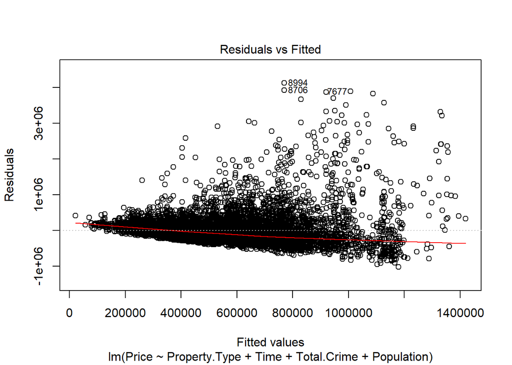

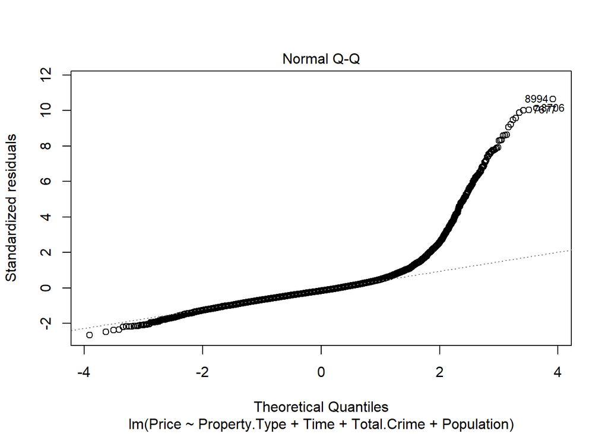

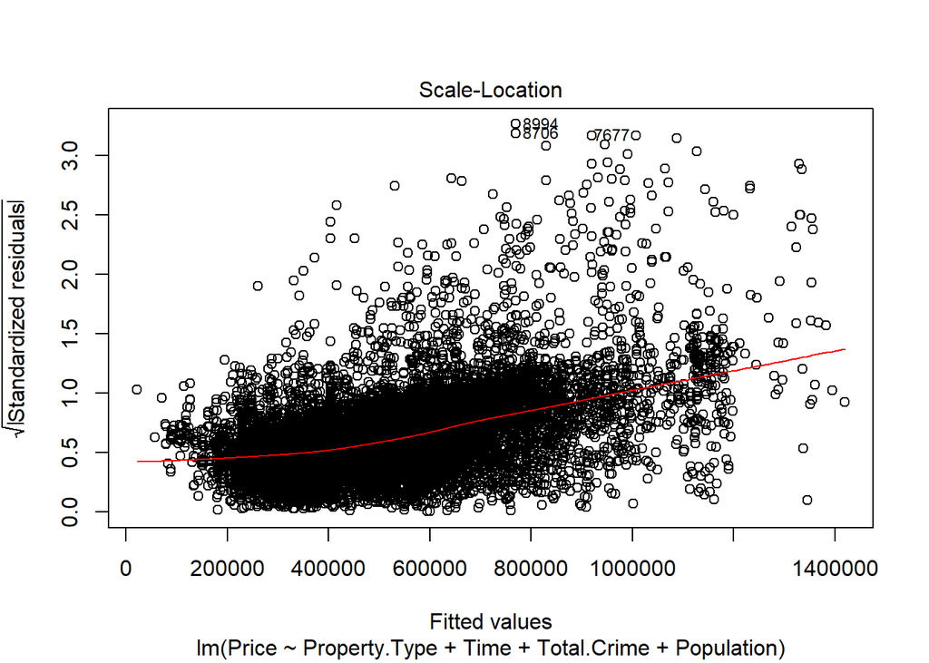

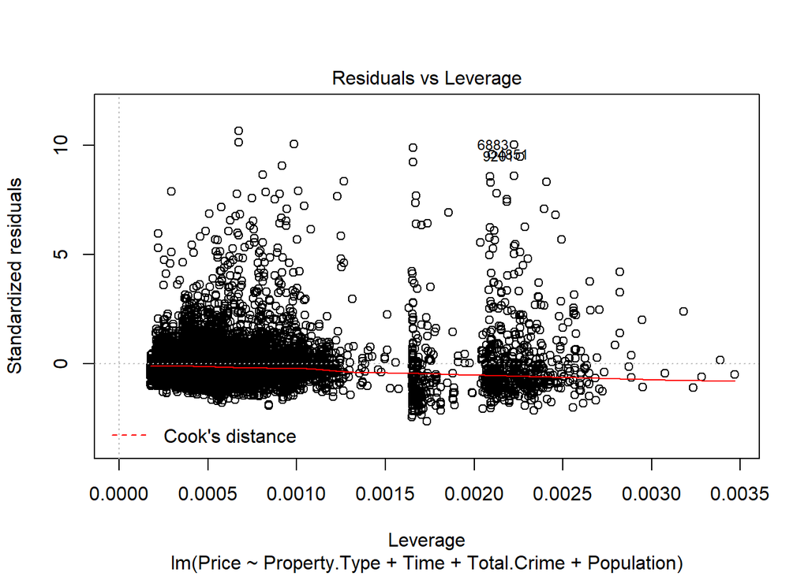

```r
plot(prop.model.best)
```

### Outputs

Whilst individual factors correlate significantly with prices, I have not been able to create an effective regression model. This is due to the large variation in the data set. The price data has a standard deviation of ~440k. Removing the major outliers has reduced this but my model still only has an adjusted R squared score of 0.2282. I suspsect that access to further information (size of property, number of rooms and age of property) would allow me to subset the data and produce a better linear model. The Q-Q plots show there is a linear relationship between factors over part of the range of data.

### Take away points

Home buyers: Properties in areas with higher crime rates but on the edges of Districts and therefore access to better schools in adjacent Districts may provide the opportunity to acquire an underpriced property

Property Websites: Inclusion of a crime rating and a graphical representation of this are features that are likely to assist buyers with selecting a property.

The R code used to wrangle and model the data can be found here: https://github.com/JJmistry/Foundations-of-data-science

### Further work

This project could be developed further in two key way: examining the problem in more detail and a wider range of factors to construct a better model. Alternatively more effort could be placed in presenting the information in a accessible way and making it usable to non-technical users, for example interactive mapping.

1. Examine data with greater granularity (down to LSOA level)
2. Further factors (green space, air pollution etc)
3. Examine historical trends
4. Compare price growth relative to changes (macro â government policy, micro â changes in local policy)
5. Plot results on an interactive R Shiny map.
6. Examine only one District but to a greater level of detail.